# Pedigree metrics

# Overview of the metrics

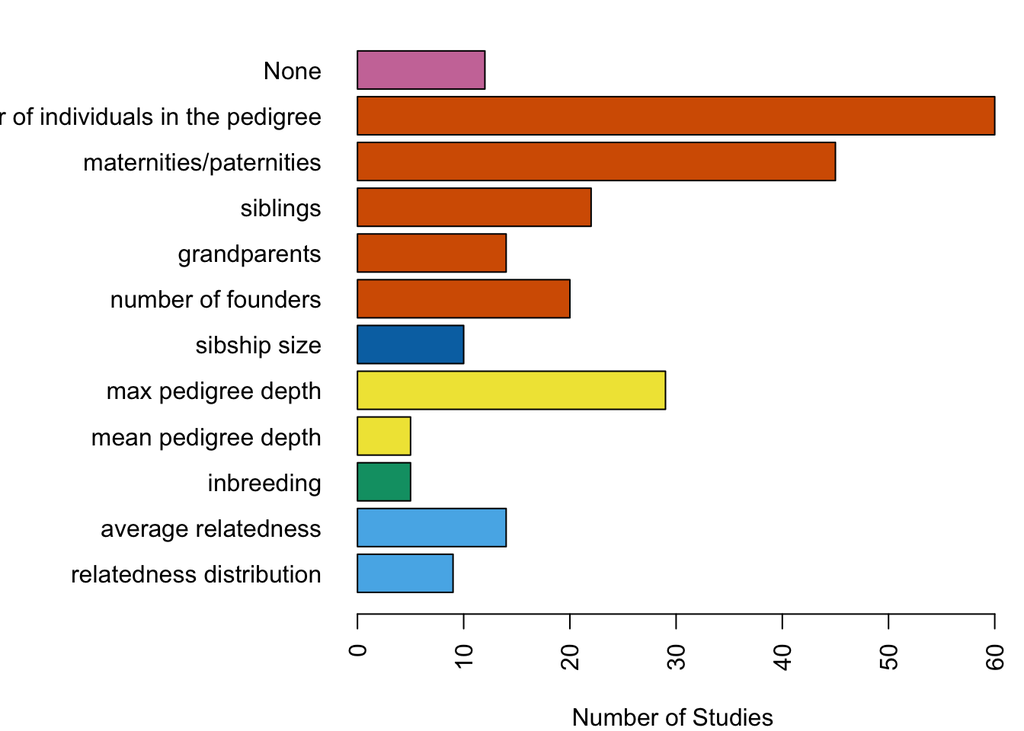

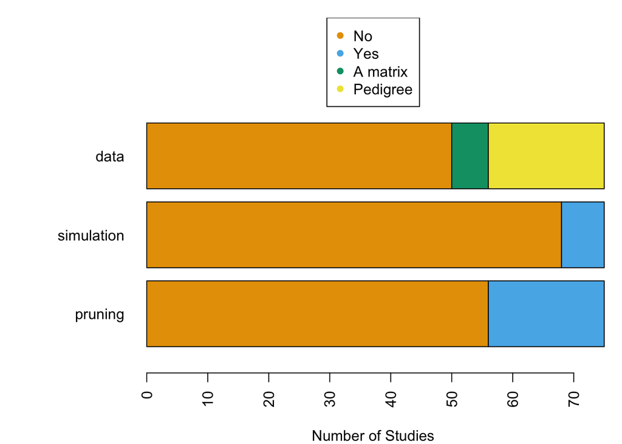

Few studies mention simulations. Discussion of pedigree pruning is more common, but still no where near ubiquitous. Only a small proportion of papers have an accompanying pedigree or A matrix.

These patterns have changed over time, for example the availability of pedigree data:

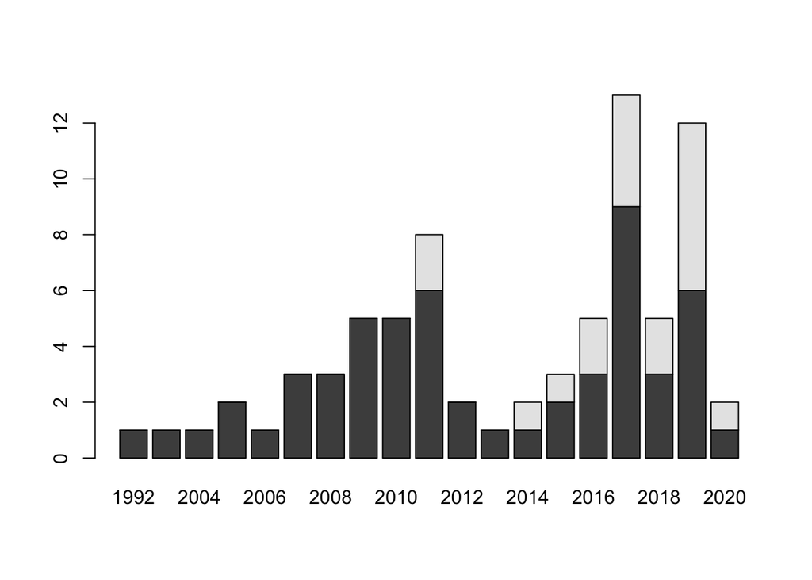

# Pedigrees

We can see that the bird pedigrees in our dataset are much larger then the mammal ones.

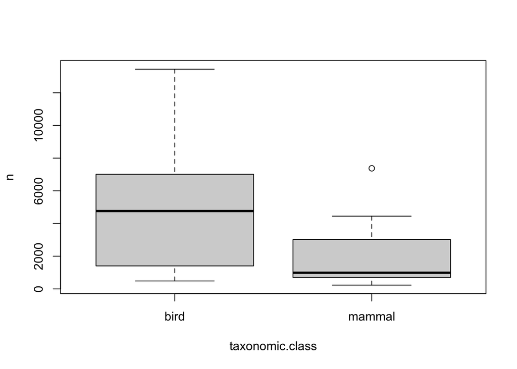

## Relationships between metrics

We can look at how all the pedantic metrics relate to each other. All metrics shown below are logged:

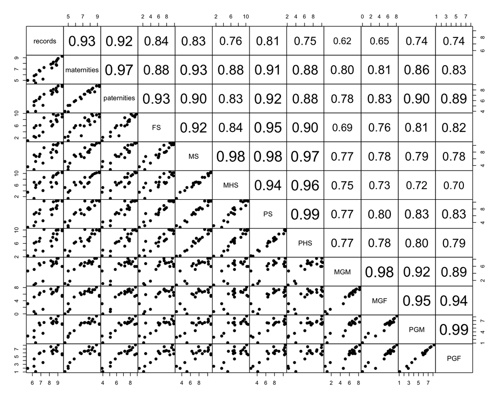

The ‘number of x relationship’ metrics are all very highly correlated. We can perhaps broadly split these into three categories overall number of records, sibling based metrics, and grandparent based metrics. Realistically, we probably need one metrics for each of these groups.

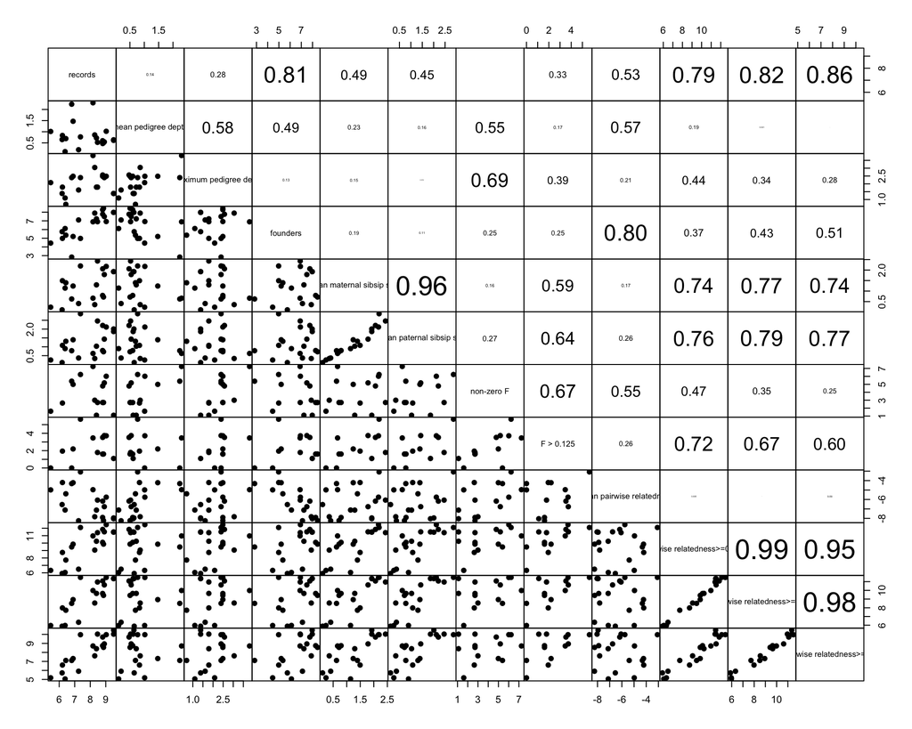

The are generally lower correlations when considering the other metrics. Again the number based metrics are all pretty highly correlated with total records, the sibship size metrics are also very highly correlated, and number based metrics for the A matrix are very highly correlated.

## Metrics and precision

We can compare each of the metrics (x axis) to precision estimated as the 1/SD of the sampling distribution estimated with $h^2$ of 0.3 and the pedigree in question (y axis).

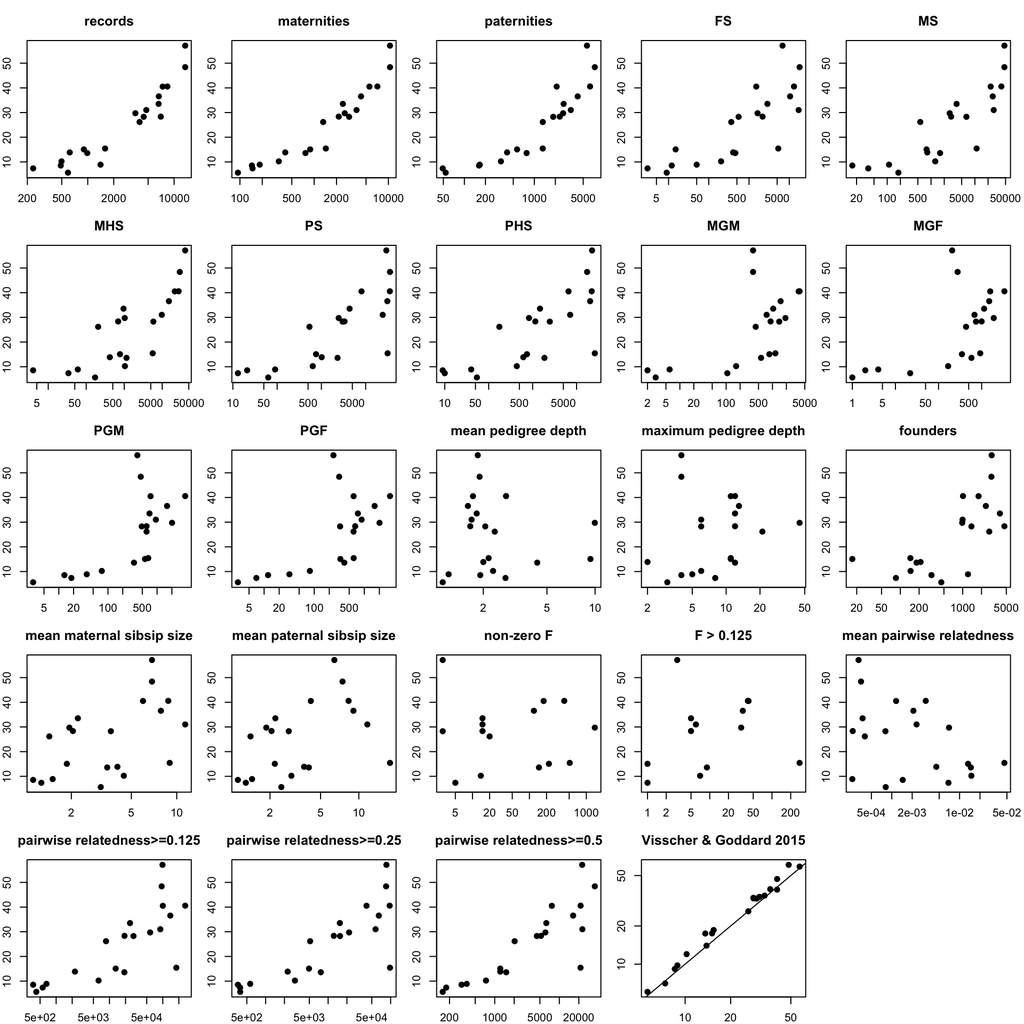

Visscher & Goddard’s (2015) precision metric is a very good predictor of precision in a simple animal model

Given the variation in pedigree size across pedigrees used in wild studies, the simple size of the pedigree (e.g. total records or maternities) is a also very good predictor of precision (better than any other).

We need to think whether we want to know how well other metrics might explain the precision of differently structured pedigrees of the same size (i.e. controlling for pedigree size), although size alone if clearly the most important factor.